# Malaria Data Science

Assigment - Week 2

Joseph maina

06 February, 2025

[figure not shown]

## Instructions

Solve the exercises below by providing the R code inside the code chunks, and the plain English answers outside (and below) the code chunks. Submit both the RMarkdown (.Rmd) file and the resulting HTML file. Data are provided in the `data` sub-folder.

## Data

A randomized clinical trial was conducted to test the efficacy of a new drug on the prevention of malaria for people travelling (visiting) to regions with high malaria transmission. The study took place in a remote village in Mozambique, in which adult visitors planning to stay for at least two months were asked to participate in the trial. The participants were enrolled within 24 hours of arrival, and randomly assigned to the receive the study drug or placebo (fake drug).

The inclusion (eligibility) criteria:

- Having 18 or more years of age
- Not having malaria infection (confirmed by negative PCR test)
- No being pregnant

The trial was blinded, i.e., participant did not know if they were taking the active drug or placebo. The trial was blinded, i.e., participant did not know if they were taking the active drug or placebo. Data were collect at two time points, at enrolment and at end of follow-up period of 2 months.

The data collected at enrolment are provided in the file `recruitment_data.csv` and contains the following variables:

- `subject_id`: the unique participant identifier assigned at enrolment
- `date_enrol`: the date of participant enrolment, format: YYYY-MM-DD
- `date_birth`: participant’s birth date, format: YYYY-MM-DD
- `sex`: participant’s sex, coded 1 (Female) and 2 (Male)
- `weight_kg`: participant’s weight in kilograms
- `height_cm`: participate height in centimetres
- `malaria_origin`: malaria transmission at the place of participant’s origin, coded 0 (no transmission), 1 (low transmission), 2 (moderate transmission), and 3 (high transmission)
- `treatment`: the treatment group assigned to the participant, coded 0 (placebo) and 1 (active drug)

The data collected at the end of follow-up is in the `end_data.csv`, with the following variables:

- `subject_id`: the unique participant identifier assigned at enrolment
- `date_end`: date of the end of follow-up visit, format: YYYY-MM-DD
- `malaria_epi`: total number of malaria episodes the participant had from the enrolment till end of follow-up
- `bednet`: use of bed net by the participant during the study period, coded 0 (never), 1(sometimes) and 2 (always)

The data files are located in the `data/orig` subfolder.

The two data files where pre-processed in R to create a single final dataset for analysis, and saved to the file `merged_data.rds` in the `data/proc` subfolder.` During the pre-processing, new variables were created, namely:

- `age_y`: age in years at enrolment
- `height_m`: height in metres at enrolment
- `bmi`: body mass index at enrolment
- `had_malaria`: whether a participant had malaria during the study follow-up period (Yes/No)

The body mass index (BMI) is a measure of body fat based on height and weight, and is calculated as
$$\text{BMI}
= \frac{\text{w}}{\text{h}^2}$$
where $w$ is weight in kilograms and $h$ is height in metres.

## Exercises

### Exercise 1

Import the final (merged) dataset into your R session, assigning to an R object named `mds`. Then print the structure of the `mds` data frame.

Are the variables data types in line with their description above?

```
TRUE 'data.frame':  1000 obs. of  15 variables:
TRUE  $ subject_id    : chr  "P0001" "P0002" "P0003" "P0004" ...
TRUE  $ date_enrol    : Date, format: "2022-10-02" "2022-10-02" ...
TRUE  $ date_birth    : Date, format: "1987-02-02" "1987-03-06" ...
TRUE  $ sex           : Factor w/ 2 levels "Female","Male": 1 2 1 2 1 2 2 1 2 2 ...
TRUE  $ weight_kg     : num  46.6 83.2 72.2 58 62.5 67.8 61.4 52.2 53.4 53.5 ...
TRUE  $ height_cm     : int  151 147 149 150 150 149 149 150 148 149 ...
TRUE  $ malaria_origin: Factor w/ 4 levels "No","Low","Moderate",..: 3 2 4 4 1 4 4 3 1 1 ...
TRUE  $ treatment     : Factor w/ 2 levels "Placebo","Active": 2 1 1 1 2 1 1 1 1 2 ...
TRUE  $ age_y         : num  35.7 35.6 35.8 35.6 35.5 ...
TRUE  $ height_m      : num  1.51 1.47 1.49 1.5 1.5 1.49 1.49 1.5 1.48 1.49 ...
TRUE  $ bmi           : num  20.4 38.5 32.5 25.8 27.8 ...
TRUE  $ date_end      : Date, format: "2022-11-30" "2022-12-01" ...
TRUE  $ malaria_epi   : int  0 0 1 1 1 1 0 0 2 1 ...
TRUE  $ bednet        : Factor w/ 3 levels "Never","Sometimes",..: 3 2 3 1 1 2 1 2 2 2 ...
TRUE  $ had_malaria   : Factor w/ 2 levels "Yes","No": 2 2 1 1 1 1 2 2 1 1 ...
```

```
TRUE   subject_id          date_enrol           date_birth             sex
TRUE  Length:1000        Min.   :2022-10-02   Min.   :1986-06-05   Female:517
TRUE  Class :character   1st Qu.:2023-01-03   1st Qu.:1987-03-23   Male  :483
TRUE  Mode  :character   Median :2023-04-05   Median :1987-05-12
TRUE                     Mean   :2023-04-03   Mean   :1987-05-12
TRUE                     3rd Qu.:2023-06-30   3rd Qu.:1987-07-04
TRUE                     Max.   :2023-10-01   Max.   :1988-01-16
TRUE    weight_kg       height_cm      malaria_origin   treatment       age_y
TRUE  Min.   :28.90   Min.   :142.0   No      :249    Placebo:485   Min.   :34.76
TRUE  1st Qu.:53.38   1st Qu.:149.0   Low     :238    Active :515   1st Qu.:35.62
TRUE  Median :59.95   Median :150.0   Moderate:250                  Median :35.87
TRUE  Mean   :60.04   Mean   :150.1   High    :263                  Mean   :35.89
TRUE  3rd Qu.:66.92   3rd Qu.:152.0                                 3rd Qu.:36.16
TRUE  Max.   :94.20   Max.   :157.0                                 Max.   :37.14
TRUE     height_m          bmi           date_end           malaria_epi
TRUE  Min.   :1.420   Min.   :12.84   Min.   :2022-11-30   Min.   :0.000
TRUE  1st Qu.:1.490   1st Qu.:23.65   1st Qu.:2023-03-04   1st Qu.:0.000
TRUE  Median :1.500   Median :26.57   Median :2023-06-04   Median :0.000
TRUE  Mean   :1.501   Mean   :26.66   Mean   :2023-06-02   Mean   :0.423
TRUE  3rd Qu.:1.520   3rd Qu.:29.66   3rd Qu.:2023-08-29   3rd Qu.:1.000
TRUE  Max.   :1.570   Max.   :41.87   Max.   :2023-11-30   Max.   :3.000
TRUE        bednet    had_malaria
TRUE  Never    :325   Yes:374
TRUE  Sometimes:334   No :626
TRUE  Always   :341
TRUE
TRUE
TRUE
```

all variables are correctly formatted and as expected every variable is there.

```r
# converting variable types
```

### Exercise 2

One thing that can affect or distort the comparison of the two treatment groups (placebo vs active drug) with regard to the outcome of interest (having malaria during the study follow-up period) is the imbalance of the participant characteristics between the two treatment groups. Construct a table containing summary statistics of participant characteristics by treatment group. The characteristics to consider are: sex, body mass index, malaria transmission at the place of origin, age, and use of bed net. Include also the p-values from the appropriate statistical tests to check whether there are significant differences (of participant characteristics) between the two groups.

Checking your output table, are there significant differences? If yes, in what characteristics?

#### Exercise 2 Solution:

```r
# Load necessary libraries
library(dplyr)
library(finalfit)
library(kableExtra)

# Define variables
v_indep <- c("sex", "bmi", "malaria_origin", "age_y", "bednet")  # Independent variables
v_dep <- "treatment"  # Treatment group (Placebo vs. Active)

# Create the summary table with p-values
mds |>
  summary_factorlist(v_dep, v_indep,
                     p = TRUE,
                     p_cont_para = 't.test',  # Use t-test for continuous variables
                     p_cat = 'chisq',         # Use chi-square test for categorical variables
                     add_dependent_label = FALSE,
                     cont = "mean",           # Show mean for continuous variables
                     total_col = FALSE,
                     add_col_totals = TRUE,
                     add_row_totals = TRUE,
                     na_include = TRUE,
                     na_to_p = FALSE,
                     na_to_prop = FALSE,
                     include_col_totals_percent = FALSE) -> treatment_comparison


# Display the table with formatting
treatment_comparison |>
  kable(caption = "Comparison of Participant Characteristics by Treatment Group") |>
  kable_styling() |>
  kable_classic(lightable_options = c('striped', 'hover'))
```

Comparison of Participant Characteristics by Treatment Group

| label | Total N | Missing N | levels | Placebo | Active | p |
| --- | --- | --- | --- | --- | --- | --- |
| Total N |  |  |  | 485 | 515 |  |
| sex | 1000 (100.0) | 0 | Female | 259 (53.4) | 258 (50.1) | 0.326 |
|  |  |  | Male | 226 (46.6) | 257 (49.9) |  |
|  |  |  | (Missing) | 0 | 0 |  |
| bmi | 1000 (100.0) | 0 | Mean (SD) | 26.8 (4.7) | 26.6 (4.5) | 0.518 |
| malaria_origin | 1000 (100.0) | 0 | No | 118 (24.3) | 131 (25.4) | 0.334 |
|  |  |  | Low | 120 (24.7) | 118 (22.9) |  |
|  |  |  | Moderate | 130 (26.8) | 120 (23.3) |  |
|  |  |  | High | 117 (24.1) | 146 (28.3) |  |
|  |  |  | (Missing) | 0 | 0 |  |
| age_y | 1000 (100.0) | 0 | Mean (SD) | 35.9 (0.4) | 35.9 (0.4) | 0.075 |
| bednet | 1000 (100.0) | 0 | Never | 166 (34.2) | 159 (30.9) | 0.442 |
|  |  |  | Sometimes | 154 (31.8) | 180 (35.0) |  |
|  |  |  | Always | 165 (34.0) | 176 (34.2) |  |
|  |  |  | (Missing) | 0 | 0 |  |

There are no significant differences between the treatment groups for any of the participant characteristics (sex, bmi, malaria_origin, age_y, bednet).Since p-values are all greater than 0.05, this means the two groups (Placebo vs. Active Drug) are well-balanced in terms of participant characteristics, reducing potential confounding.

### Exercise 3

We are interested in comparing, visually, the distribution of the body mass index between the two treatment groups. Use a box plot to achieve this goal.

What are your conclusions? Are there any outliers?

#### Exercise 3 Solution:

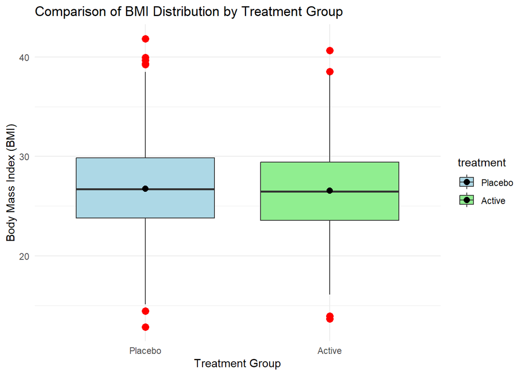

[figure not shown]

```r
# Load required libraries
library(ggplot2)
library(ggpubr)

# Create the box plot
ggplot(mds, aes(x = treatment, y = bmi, fill = treatment)) +
  geom_boxplot(outlier.color = "red", outlier.shape = 16, outlier.size = 3) +
  labs(title = "Comparison of BMI Distribution by Treatment Group",
       x = "Treatment Group",
       y = "Body Mass Index (BMI)") +
  theme_minimal() +
  scale_fill_manual(values = c("Placebo" = "lightblue", "Active" = "lightgreen")) +
  stat_summary(fun = mean, geom = "point", shape = 20, size = 4, color = "black")  # Adds mean marker
```

##handling the outliers

```
TRUE    subject_id date_enrol date_birth    sex weight_kg height_cm malaria_origin
TRUE 1       P0031 2022-10-14 1987-07-27   Male      30.3       149           High
TRUE 2       P0080 2022-10-31 1987-08-13 Female      94.2       150       Moderate
TRUE 3       P0119 2022-11-12 1987-02-09   Male      32.5       150             No
TRUE 4       P0207 2022-12-20 1987-06-13   Male      86.0       148            Low
TRUE 5       P0254 2023-01-03 1986-11-22 Female      87.9       147           High
TRUE 6       P0327 2023-02-01 1987-02-12 Female      28.9       150             No
TRUE 7       P0531 2023-04-15 1987-05-31   Male      84.6       146           High
TRUE 8       P0671 2023-06-04 1987-03-31   Male      30.5       148       Moderate
TRUE 9       P0760 2023-07-04 1987-03-04   Male      86.4       147             No
TRUE 10      P0808 2023-07-20 1987-03-24   Male      32.9       151           High
TRUE 11      P0978 2023-09-24 1987-07-02   Male      88.5       150           High
TRUE    treatment    age_y height_m      bmi   date_end malaria_epi    bednet
TRUE 1     Active 35.21697     1.49 13.64803 2022-12-14           0    Always
TRUE 2    Placebo 35.21697     1.50 41.86667 2022-12-31           1    Always
TRUE 3    Placebo 35.75633     1.50 14.44444 2023-01-12           1 Sometimes
TRUE 4    Placebo 35.52088     1.48 39.26224 2023-02-18           0 Sometimes
TRUE 5     Active 36.11499     1.47 40.67750 2023-03-04           0 Sometimes
TRUE 6    Placebo 35.96988     1.50 12.84444 2023-04-02           0 Sometimes
TRUE 7    Placebo 35.87406     1.46 39.68850 2023-06-14           1    Always
TRUE 8     Active 36.17796     1.48 13.92440 2023-08-03           0    Always
TRUE 9    Placebo 36.33402     1.47 39.98334 2023-09-02           2 Sometimes
TRUE 10   Placebo 36.32307     1.51 14.42919 2023-09-18           1     Never
TRUE 11   Placebo 36.22998     1.50 39.33333 2023-11-23           1 Sometimes
TRUE    had_malaria
TRUE 1           No
TRUE 2          Yes
TRUE 3          Yes
TRUE 4           No
TRUE 5           No
TRUE 6           No
TRUE 7          Yes
TRUE 8           No
TRUE 9          Yes
TRUE 10         Yes
TRUE 11         Yes
```

Instead of removing the ouliers i replaced them with lower and upper bounds

```
TRUE    Min. 1st Qu.  Median    Mean 3rd Qu.    Max.
TRUE   14.63   23.65   26.57   26.65   29.66   38.68
```

### Exercise 4

The main objective of the study was to evaluate the efficacy of the new drug (active drug) in preventing malaria infection. That is, we hypothesize that the new drug reduces the probability of getting malaria infection, compared to placebo. Some participant characteristics might be malaria risk factors (i.e., associated with malaria). It is, therefore, important to check for this associations before performing the confirmatory analysis.

Check for possible associations between the participant characteristics and the outcome (`had_malaria`). The characteristics to check are: `sex`, `bmi`, `age`, and `bednet`. Present in form of table, similar to that of the Exercise 2. Include also the p-values.

What insights are getting from your output?

#### Exercise 4 Solution:

```r
# Load necessary libraries
library(dplyr)
library(finalfit)
library(kableExtra)

# Define variables
v_indep <- c("sex", "bmi", "age_y", "bednet")  # Independent variables
v_dep <- "had_malaria"  # Dependent variable

# Create summary table with p-values
mds |>
  summary_factorlist(v_dep, v_indep,
                     p = TRUE,
                     p_cont_para = 't.test',  # Use t-test for continuous variables
                     p_cat = 'chisq',         # Use chi-square test for categorical variables
                     add_dependent_label = FALSE,
                     cont = "mean",           # Show mean for continuous variables
                     total_col = FALSE,
                     add_col_totals = TRUE,
                     add_row_totals = TRUE,
                     na_include = TRUE,
                     na_to_p = FALSE,
                     na_to_prop = FALSE,
                     include_col_totals_percent = FALSE) -> malaria_risk_factors

# Display the table with formatting
malaria_risk_factors |>
  kable(caption = "Association Between Participant Characteristics and Malaria Outcome") |>
  kable_styling() |>
  kable_classic(lightable_options = c('striped', 'hover'))
```

Association Between Participant Characteristics and Malaria Outcome

| label | Total N | Missing N | levels | Yes | No | p |
| --- | --- | --- | --- | --- | --- | --- |
| Total N |  |  |  | 374 | 626 |  |
| sex | 1000 (100.0) | 0 | Female | 191 (51.1) | 326 (52.1) | 0.808 |
|  |  |  | Male | 183 (48.9) | 300 (47.9) |  |
|  |  |  | (Missing) | 0 | 0 |  |
| bmi | 1000 (100.0) | 0 | Mean (SD) | 27.1 (4.6) | 26.4 (4.6) | 0.025 |
| age_y | 1000 (100.0) | 0 | Mean (SD) | 35.9 (0.4) | 35.9 (0.4) | 0.196 |
| bednet | 1000 (100.0) | 0 | Never | 149 (39.8) | 176 (28.1) | 0.001 |
|  |  |  | Sometimes | 115 (30.7) | 219 (35.0) |  |
|  |  |  | Always | 110 (29.4) | 231 (36.9) |  |
|  |  |  | (Missing) | 0 | 0 |  |

### Exercise 5

Suppose that, for answering the main research question, we are going to used multivariate logistic regression, having the variable `had_malaria` as the dependent variable and the `treatment` as one of the independent variables. Looking at your output of Exercise 4, what other independent variable would you include in the model?

#### Exercise 5 Solution:

Based on the univariate analysis, the independent variables BMI and bednet usage should be included in the multivariate logistic regression model alongside the treatment variable, as they show significant associations with the outcome (had_malaria).

The final model would include:

1. Treatment (as one of the independent variables)
2. BMI
3. Bednet Usage

```
TRUE
TRUE Call:
TRUE glm(formula = had_malaria ~ treatment + bmi + bednet, family = binomial,
TRUE     data = mds)
TRUE
TRUE Coefficients:
TRUE                 Estimate Std. Error z value Pr(>|z|)
TRUE (Intercept)      0.49216    0.41905   1.174 0.240213
TRUE treatmentActive  1.02304    0.13676   7.481  7.4e-14 ***
TRUE bmi             -0.03033    0.01484  -2.044 0.040974 *
TRUE bednetSometimes  0.45695    0.16549   2.761 0.005760 **
TRUE bednetAlways     0.57144    0.16603   3.442 0.000578 ***
TRUE ---
TRUE Signif. codes:  0 '***' 0.001 '**' 0.01 '*' 0.05 '.' 0.1 ' ' 1
TRUE
TRUE (Dispersion parameter for binomial family taken to be 1)
TRUE
TRUE     Null deviance: 1322.1  on 999  degrees of freedom
TRUE Residual deviance: 1244.7  on 995  degrees of freedom
TRUE AIC: 1254.7
TRUE
TRUE Number of Fisher Scoring iterations: 4
```

Based on the model the variables are statisticallly significant.this indicates that treatment,bmi and the use of bednet is relevant and should be considered for decision making with respect to malaria.